# Statistical inference with the GSS data

## Setup

### Load packages

```r
library(ggplot2)
library(dplyr)
library(statsr)
```

### Load data

```r
load("/Users/iBowen/Desktop/stat/stat_coursera/project2/gss.Rdata")
```

## Part 1: Data

**As mentioned in the Codebook, the observation data is collected by computer-assisted personal interview (CAPI), face-to-face interview, and telephone interview. There is no experiment assignment occuring int sampling. Hence, the research question below could only produce generalizability but not causality.**

## Part 2: Research question

**Does there appear to be a relationship between political party affiliation and region of interview?**

## Part 3: Exploratory data analysis

```r
# subset political party affiliation as 'partyid' and region of interview as 'region'
data <- gss[, c('partyid', 'region')]
table(data)
```

```
##                     region
## partyid              New England Middle Atlantic E. Nor. Central
##   Strong Democrat            361            1292            1704
##   Not Str Democrat           463            1975            2011
##   Ind,Near Dem               479             976            1342
##   Independent                457            1272            1673
##   Ind,Near Rep               345             586             964
##   Not Str Republican         308            1458            1670
##   Strong Republican          208             668             983
##   Other Party                 41             143             162
##                     region
## partyid              W. Nor. Central South Atlantic E. Sou. Central
##   Strong Democrat                600           2026             709
##   Not Str Democrat               796           2306             813
##   Ind,Near Dem                   543           1100             365
##   Independent                    601           1588             513
##   Ind,Near Rep                   406            895             326
##   Not Str Republican             763           1678             603
##   Strong Republican              442           1206             365
##   Other Party                     53            116              42
##                     region
## partyid              W. Sou. Central Mountain Pacific
##   Strong Democrat                936      401    1088
##   Not Str Democrat              1238      664    1774
##   Ind,Near Dem                   579      437     922
##   Independent                    810      487    1098
##   Ind,Near Rep                   489      338     572
##   Not Str Republican             708      598    1219
##   Strong Republican              496      419     761
##   Other Party                     83       63     158
```

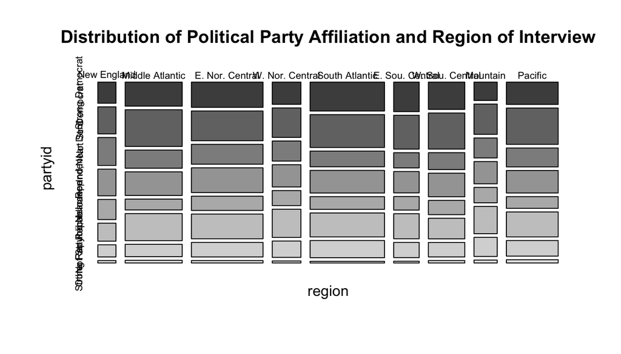

```r
# each cell has at least 5 cases

# make a mosaic plot to show the distribution under party and affiliation
mosaicplot(~ region + partyid, data = data, main = 'Distribution of Political Party Affiliation and Region of Interview', color = TRUE)
```

```r
# note: I couldn't find a solution to handle label overlapping, but it won't affect to find the proportion difference inbetween each cell.
```

As shown in the plotting, the proportions are different along each variable. But before we confirm a dependent relationship between these two variables, an inference test is needed. Since we have two categorical varaibles, so a Chi-Square statistics is used to test the independence between party affiliation and region of interview.

## Part 4: Inference

**Step 1. Check the condition**

Independence:

- Random sample/assignment: the observations are collected by independent interview.
- If sampling without replacement, n < 10% of population. The total data points are 57,061, absolutly less than the 10% of US popluation.
- Each case only contributes to one cell in the table.

Sample size:

- Each particular scenario must have at least 5 expected cases. The minimum cell is 41

So, it meets the condiiton for Chi-Square test

**Step 2. Build the Null and Alternative Hypothesis**

H0: Political affiliation and region of interview are independent. Political affiliation does not vary by region of interview.

HA: Political affiliation and region of interview are dependent. Political affiliation does vary by region of interview.

**Step 3. Implement the Chi-Square Independent Test**

```r
# transform table into dataframe with NA removed
matrix.obs <- as.data.frame.matrix(table(data))
# calculate rowsum and colsum
rowtotal <- rowSums(matrix.obs)
coltotal <- colSums(matrix.obs)
# record the total value
total <- sum(rowtotal)
# calculate expected matrix
matrix.exp <- (rowtotal / total) %*% t(coltotal)
# calculate X2 and degree of freedom
X2 <- sum((matrix.obs - matrix.exp) ^ 2 / matrix.exp)
df <- (dim(matrix.obs)[1] - 1) * (dim(matrix.obs)[2] - 1)
# calculate the p-value
pchisq(X2, df, lower.tail = FALSE)
```

```
## [1] 4.778456e-121
```

**Conclusion** we can find the p-value is extremely small compared the 5% significant level, so we are going to reject the H0, and accect the HA. That means, there is a associaiton between the region of interview and political affiliation.